# Car Evaluation 🚗

## Lab Four: Extending Logistic Regression

### Justin Ledford, Luke Wood, Traian Pop

## Preparation and Overview

### Use-case

The classification task in this dataset is broken into 4 classes. This includes 'unacc' (unacceptable), 'acc' (acceptable), 'good' (good!), and 'v-good' (very good!). These conditions decrease in percentage in the dataset as you go down the list. There are a high value of "unacceptable" with almost 70% of the data belonging to this class, about 22% "acceptable", and about 4% each for "good" and "very good".

This dataset could be used to create a recommendation engine for people looking to buy new cars (Or cars that are new to them 😀). When a person is looking for a car, they could simply get the different attributes and use the classifier to check how satisfied people tend to be with the car. The possibilities for a classifier for cars is limitless considering both the vehicle industry in the US and internationally is booming since more and more people are desiring new and improved cars. A classifier that could accurately predict the satisfaction of a car could be both beneficial to a consumer (they would spend less time looking for cars and more time buying) or even a seller (less time they have to spend on negotiating/buying cars means more time selling products). It could also be helpful for consumer guides and car reviews to filter out cars based on the satisfaction rating from this model, as well as assist car dealerships in purchasing inventory.

### Data preparation

The data originally consisted of categorical attributes with each value as a string:

buying: v-high, high, med, low  
maintain: v-high, high, med, low  
doors: 2, 3, 4, 5-more  
persons: 2, 4, more  
trunk: small, med, big  
safety: low, med, high

We converted the attributes to one hot encoding, and converted the class values to integers (0-3). Since the dataset only has a small amount of attributes, we decided to keep all of them, and that dimensionality reduction was not necessary with this data.

```python
import numpy as np
import plotly
import pandas as pd
import matplotlib.pyplot as plt
import time

import warnings
warnings.filterwarnings('ignore')

#one-hot encoding method
df = pd.read_csv(
        'http://archive.ics.uci.edu/ml/machine-learning-databases/car/car.data',
        header=None)

df.columns = ['buying', 'maint', 'doors', 'persons', 'trunk', 'safety', 'class']

# One hot encode caegorical attributes
df_dummies = pd.get_dummies(df.drop('class', axis=1))

# Convert class to integers
y = df['class'].replace(to_replace=['unacc', 'acc', 'good', 'vgood'],
                        value=range(4)).values
X = df_dummies.values
```

```python
#number representation method
df_n = pd.read_csv('https://archive.ics.uci.edu/ml/machine-learning-databases/car/car.data', header=None)

df_n.columns=['buying','maint', 'doors', 'persons', 'lug_boot', 'safety', 'class']
classes = ['unacc', 'acc', 'good', 'vgood']

y_n = df_n['class']
y_n.replace(to_replace=classes, value=range(4), inplace=True)

X_n = df_n.drop('class', 1)

X_n.buying.replace(to_replace=['vhigh', 'high', 'med', 'low'], value=range(4), inplace=True)
X_n.maint.replace(to_replace=['vhigh', 'high', 'med', 'low'], value=range(4), inplace=True)
X_n.doors.replace(to_replace='5more', value=5, inplace=True)
X_n.persons.replace(to_replace='more', value=6, inplace=True)
X_n.lug_boot.replace(to_replace=['small', 'med', 'big'], value=range(3), inplace=True)
X_n.safety.replace(to_replace=['low', 'med', 'high'], value=range(3), inplace=True)

X_n = X_n.astype(np.int64).values
y_n = y_n.values
```

```python
plotly.offline.init_notebook_mode() # run at the start of every notebook

graph1 = {'labels': ['Unacceptable', 'Acceptable', 'Good', 'Very good'],
          'values': np.bincount(y),
            'type': 'pie'}
fig = dict()
fig['data'] = [graph1]
fig['layout'] = {'title': 'Class Distribution',
                'autosize':False,
                'width':500,
                'height':300}

plotly.offline.iplot(fig)
```

[interactive chart not shown]

## Splitting data into training and testing sets

Now using ShuffleSplit we can split our data set into a training set consisting of 80% of the instances, and a testing set consisting of 20% of the instances.

```python
from sklearn.model_selection import ShuffleSplit

# split into 80/20 training/test data
num_cv_iterations = 1
cv_object = ShuffleSplit(n_splits=num_cv_iterations, test_size = 0.2)

for train_indices, test_indices in cv_object.split(X,y):
    X_train = X[train_indices]
    y_train = y[train_indices]

    X_test = X[test_indices]
    y_test = y[test_indices]
```

Since our instances from the classes "good" and "very good" are each only represented by 4% of the instances, there is a chance that the 80% of data used for training does not contain either of those classes at all. We all agree that because of this reason, our data would NOT be good for a regular 80/20 split no matter how randomized of a cross validation model we use.

## Modeling

### Creating one-versus all logistic regression classifier

First we define all the basic regression methods that we will build upon. These were taken from Professor Eric Larson's Logistic Optimization Jupyter Notebook.

```python
import numpy as np
from scipy.special import expit
from sklearn.metrics import accuracy_score
from numpy.linalg import pinv

# all these classes taken from Larson's notebook 5. Logistic Regression

class BinaryLogisticRegressionBase:
    # private:
    def __init__(self, eta, iterations=20):
        self.eta = eta
        self.iters = iterations
        # internally we will store the weights as self.w_ to keep with sklearn conventions

    def __str__(self):
        return 'Base Binary Logistic Regression Object, Not Trainable'

    # convenience, private:
    @staticmethod
    def _sigmoid(theta):
        return 1/(1+np.exp(-theta))

    @staticmethod
    def _add_bias(X):
        return np.hstack((np.ones((X.shape[0],1)),X)) # add bias term

    # public:
    def predict_proba(self,X,add_bias=True):
        # add bias term if requested
        Xb = self._add_bias(X) if add_bias else X
        return self._sigmoid(Xb @ self.w_) # return the probability y=1

    def predict(self,X):
        return (self.predict_proba(X)>0.5) #return the actual prediction


class BinaryLogisticRegression(BinaryLogisticRegressionBase):
    #private:
    def __str__(self):
        if(hasattr(self,'w_')):
            return 'Binary Logistic Regression Object with coefficients:\n'+ str(self.w_) # is we have trained the object
        else:
            return 'Untrained Binary Logistic Regression Object'

    def _get_gradient(self,X,y):
        # programming \sum_i (yi-g(xi))xi
        gradient = np.zeros(self.w_.shape) # set gradient to zero
        for (xi,yi) in zip(X,y):
            gradi = (yi - self.predict_proba(xi,add_bias=False))*xi # the actual update inside of sum
            gradient += gradi.reshape(self.w_.shape) # reshape to be column vector and add to gradient

        return gradient/float(len(y))

    # public:
    def fit(self, X, y):
        Xb = self._add_bias(X) # add bias term
        num_samples, num_features = Xb.shape

        self.w_ = np.zeros((num_features,1)) # init weight vector to zeros

        # for as many as the max iterations
        for _ in range(self.iters):
            gradient = self._get_gradient(Xb,y)
            self.w_ += gradient*self.eta # multiply by learning rate


class VectorBinaryLogisticRegression(BinaryLogisticRegression):
    # inherit from our previous class to get same functionality
    @staticmethod
    def _sigmoid(theta):
        # increase stability, redefine sigmoid operation
        return expit(theta) #1/(1+np.exp(-theta))

    # but overwrite the gradient calculation
    def _get_gradient(self,X,y):
        ydiff = y-self.predict_proba(X,add_bias=False).ravel() # get y difference
        gradient = np.mean(X * ydiff[:,np.newaxis], axis=0) # make ydiff a column vector and multiply through

        return gradient.reshape(self.w_.shape)


class LogisticRegression:
    def __init__(self, eta, iterations=20):
        self.eta = eta
        self.iters = iterations
        # internally we will store the weights as self.w_ to keep with sklearn conventions

    def __str__(self):
        if(hasattr(self,'w_')):
            return 'MultiClass Logistic Regression Object with coefficients:\n'+ str(self.w_) # is we have trained the object
        else:
            return 'Untrained MultiClass Logistic Regression Object'

    def fit(self,X,y):
        num_samples, num_features = X.shape
        self.unique_ = np.unique(y) # get each unique class value
        num_unique_classes = len(self.unique_)
        self.classifiers_ = [] # will fill this array with binary classifiers

        for i,yval in enumerate(self.unique_): # for each unique value
            y_binary = y==yval # create a binary problem
            # train the binary classifier for this class
            blr = VectorBinaryLogisticRegression(self.eta,self.iters)
            blr.fit(X,y_binary)
            # add the trained classifier to the list
            self.classifiers_.append(blr)

        # save all the weights into one matrix, separate column for each class
        self.w_ = np.hstack([x.w_ for x in self.classifiers_]).T

    def predict_proba(self,X):
        probs = []
        for blr in self.classifiers_:
            probs.append(blr.predict_proba(X)) # get probability for each classifier

        return np.hstack(probs) # make into single matrix

    def predict(self,X):
        return np.argmax(self.predict_proba(X),axis=1) # take argmax along row
```

In the next part we start building a binary logistic regression class, and implementing the steepest descent, stochastic gradient descent, and Newton's method optimization techniques. A user is able to select whichever one he wants by simply replacing the method parameter with 'steepest', ' stochastic', or 'Newton' respectively.

In addition, we also added a customizable regularization term that you can use to switch between no regularization, L1 regularization, L2 regularization, or both. In order to change this parameter, simple change the value of reg to '', 'L1','L2', or 'L1L2' for each respective function.

```python
class RegularizedBinaryLogisticRegression(BinaryLogisticRegression):
    # extend init functions
    def __init__(self, reg='L2', C=0.0, method='steepest', **kwds):
        # need to add to the original initializer
        self.reg = reg
        self.C = C
        self.method = method
        # but keep other keywords
        super().__init__(**kwds) # call parent initializer

    #added steepest descent functionality
    def _steepest_descent_gradient(self, X, y):
        ydiff = y-self.predict_proba(X,add_bias=False).ravel() # get y difference
        gradient = np.mean(X * ydiff[:,np.newaxis], axis=0) # make ydiff a column vector and multiply through

        return gradient.reshape(self.w_.shape)


    def _stochastic_gradient(self, X, y):
        idx = int(np.random.rand()*len(y)) # grab random instance
        ydiff = y[idx]-self.predict_proba(X[idx],add_bias=False) # get y difference (now scalar)
        gradient = X[idx] * ydiff[:,np.newaxis] # make ydiff a column vector and multiply through
        gradient = gradient.reshape(self.w_.shape)

        return gradient


    def _newton_gradient(self, X, y):
        g = self.predict_proba(X,add_bias=False).ravel() # get sigmoid value for all classes
        hessian = X.T @ np.diag(g*(1-g)) @ X - 2 * self.C # calculate the hessian

        ydiff = y-g # get y difference
        gradient = np.sum(X * ydiff[:,np.newaxis], axis=0) # make ydiff a column vector and multiply through
        gradient = gradient.reshape(self.w_.shape)
        return pinv(hessian) @ gradient


    # extend previous class to change functionality
    def _get_gradient(self,X,y):
        # call get gradient from previous class
        if self.method == 'steepest':
            gradient = self._steepest_descent_gradient(X,y)
        elif self.method == 'stochastic':
            gradient = self._stochastic_gradient(X,y)
        elif self.method == 'newton':
            gradient = self._newton_gradient(X,y)
        else:
            return

        # add in regularization (to all except bias term)
        if self.reg == 'L2':
            gradient[1:] += -2 * self.w_[1:] * self.C
        elif self.reg == 'L1':
            gradient[1:] += -self.C
        elif self.reg == 'L1L2':
            gradient[1:] += -self.C - 2 * self.w_[1:] * self.C
        elif self.reg == 'none':
            pass

        return gradient
```

Next, we implemented the "one-versus-all", multiclass logistic regression class that utilizes the binary logistic regression class above. We also implemented additional methods to conform to scikit-learn's estimator interface in order to pass an object of our class to scikit-learn's GridSearchCV.

These methods include: get_params, set_params, and score. The first two methods do pretty much exactly what you'd expect. Score simply computes the accuracy of the model by passing it a test dataset of X and y. This is essentially a wrapper for the predict method and computing the accuracy score with the resulting y_hat with the y test vector.

The estimator interface also requires the fit and predict methods which we already had implemented in our class, thanks to Eric Larson's Regression Optimization Jupyter Notebook.

```python
# now redefine the Logistic Regression Function where needed
class RegularizedLogisticRegression(LogisticRegression):
    def __init__(self, reg='L2', C=0.0, method='steepest',
                 eta=0.01, iterations=5,**kwds):
        # need to add to the original initializer
        self.C = C
        self.method = method
        self.reg = reg
        self.eta = eta
        self.iterations = iterations
        # but keep other keywords
        super().__init__(eta=eta, iterations=iterations,**kwds) # call parent initializer


    # methods for estimator interface
    def get_params(self, deep=True):
    # suppose this estimator has parameters "alpha" and "recursive"
        return {"C": self.C, "method": self.method, "reg": self.reg}

    def set_params(self, **parameters):
        for parameter, value in parameters.items():
            self.__setattr__(parameter, value)
        return self

    def score(self, X, y):
        y_hat = self.predict(X)
        return accuracy_score(y,y_hat)

    def fit(self,X,y):
        num_samples, num_features = X.shape
        self.unique_ = np.unique(y) # get each unique class value
        num_unique_classes = len(self.unique_)
        self.classifiers_ = [] # will fill this array with binary classifiers

        for i,yval in enumerate(self.unique_): # for each unique value
            y_binary = y==yval # create a binary problem
            # train the binary classifier for this class
            blr = RegularizedBinaryLogisticRegression(eta=self.eta,
                                                      iterations=self.iters,
                                                      reg=self.reg,
                                                      method=self.method, C=self.C)
            blr.fit(X,y_binary)
            # add the trained classifier to the list
            self.classifiers_.append(blr)

        # save all the weights into one matrix, separate column for each class
        self.w_ = np.hstack([x.w_ for x in self.classifiers_]).T
```

### Training the Data

We experimented with each of the different methods with a range of values on 3 different splits. Below we run what we found to be best general parameters for each of the methods and compare the accuracy for each.

```python
from sklearn.model_selection import ShuffleSplit
from sklearn import metrics as mt

num_cv_iterations = 3
num_instances = len(y)
cv_object = ShuffleSplit(
                         n_splits=num_cv_iterations,
                         test_size  = 0.2)

for iter_num, (train_indices, test_indices) in enumerate(cv_object.split(X,y)):
    X_train = X[train_indices]
    y_train = y[train_indices]

    X_test = X[test_indices]
    y_test = y[test_indices]


    lr_clf = RegularizedLogisticRegression(eta=5,iterations=500,
                                       reg='L2', method='steepest',C=0.0001)

    lr_clf.fit(X_train, y_train)
    y_hat = lr_clf.predict(X_test)


    # print the accuracy and confusion matrix
    print("====Iteration",iter_num,": Steepest Descent ====")
    print("accuracy", mt.accuracy_score(y_test,y_hat))
    print("confusion matrix\n",mt.confusion_matrix(y_test,y_hat))

    lr_clf = RegularizedLogisticRegression(eta=0.1,iterations=500,
                                       reg='L1L2', method='stochastic',C=0.0001)

    lr_clf.fit(X_train, y_train)
    y_hat = lr_clf.predict(X_test)

    # print the accuracy and confusion matrix
    print("====Iteration",iter_num,": Stochastic ====")
    print("accuracy", mt.accuracy_score(y_test,y_hat))
    print("confusion matrix\n",mt.confusion_matrix(y_test,y_hat))

    lr_clf = RegularizedLogisticRegression(eta=0.7,iterations=20,
                                       method='newton',C=0.01, reg='L2')


    lr_clf.fit(X_train, y_train)
    y_hat = lr_clf.predict(X_test)

    # print the accuracy and confusion matrix
    print("====Iteration",iter_num,": Newton====")
    print("accuracy", mt.accuracy_score(y_test,y_hat))
    print("confusion matrix\n",mt.confusion_matrix(y_test,y_hat))
```

```
====Iteration 0 : Steepest Descent ====
accuracy 0.881502890173
confusion matrix
 [[231   9   1   0]
 [ 19  64   3   0]
 [  0   6   3   2]
 [  0   1   0   7]]
====Iteration 0 : Stochastic ====
accuracy 0.861271676301
confusion matrix
 [[224  17   0   0]
 [ 12  74   0   0]
 [  0  11   0   0]
 [  0   8   0   0]]
====Iteration 0 : Newton====
accuracy 0.881502890173
confusion matrix
 [[235   5   1   0]
 [ 24  59   3   0]
 [  0   7   3   1]
 [  0   0   0   8]]
====Iteration 1 : Steepest Descent ====
accuracy 0.890173410405
confusion matrix
 [[227  16   0   0]
 [  6  68   0   0]
 [  0  10   3   3]
 [  0   3   0  10]]
====Iteration 1 : Stochastic ====
accuracy 0.823699421965
confusion matrix
 [[233  10   0   0]
 [ 22  52   0   0]
 [  2  14   0   0]
 [  0  13   0   0]]
====Iteration 1 : Newton====
accuracy 0.898843930636
confusion matrix
 [[234   9   0   0]
 [ 11  63   0   0]
```

[output cut: 8 more lines]

```
 [  0   2   0   9]]
====Iteration 2 : Stochastic ====
accuracy 0.864161849711
confusion matrix
 [[246   8   0   0]
 [ 20  50   1   0]
 [  0   7   3   0]
 [  0   9   2   0]]
====Iteration 2 : Newton====
accuracy 0.921965317919
confusion matrix
 [[251   3   0   0]
 [ 14  54   3   0]
 [  0   5   4   1]
 [  0   1   0  10]]
```

Although the results were close, we decided that Newton's method gives us the highest accuracy.

Since we are training the model with a different set than the set we are using to test accuracy, we think our method of selecting parameters is justified, and that no data snooping is involved.

### Ours vs Scikit

Next we compare our logistic regression against scikit-learn's implementation.

```python
%%time
%load_ext memory_profiler

start = time.time()
lr = RegularizedLogisticRegression(eta=0.7,iterations=20, reg='L1L2',
                                   method='newton',C=0.01)

%memit lr.fit(X_train, y_train)
ourScore = lr.score(X_test, y_test)
end = time.time()
ourTime = end-start
```

```
peak memory: 147.34 MiB, increment: 0.05 MiB
CPU times: user 2.65 s, sys: 295 ms, total: 2.94 s
Wall time: 767 ms
```

```python
print("Accuracy:",ourScore)
```

```
Accuracy: 0.921965317919
```

```python
%%time
from sklearn.linear_model import LogisticRegression as SKLogisticRegression

start = time.time()

lr_sk = SKLogisticRegression()
%memit lr_sk.fit(X_train, y_train)
skScore = lr_sk.score(X_test, y_test)

end = time.time()
skTime = end - start
```

```
peak memory: 151.23 MiB, increment: 0.73 MiB
CPU times: user 997 ms, sys: 53.8 ms, total: 1.05 s
Wall time: 294 ms
```

```python
print('SkAccuracy:', skScore)
```

```
SkAccuracy: 0.913294797688
```

We can see that our logistic regression is a bit more accurate, but much slower.

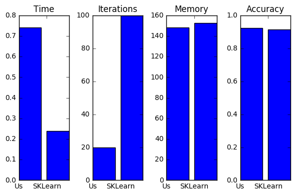

```python
fig, axes = plt.subplots(nrows=1, ncols=4)

plt.setp(axes, xticks=[0, 1], xticklabels=['Us', 'SKLearn'])

y_axis = [ourTime, skTime]
x_axis = [0, 1]
plt.sca(axes[0])
plt.bar(x_axis, y_axis, color='blue')
axes[0].set_title('Time')

plt.sca(axes[1])
y_axis = [20, 100]
x_axis = [0, 1]
plt.bar(x_axis, y_axis, color="blue")
axes[1].set_title('Iterations')

plt.sca(axes[2])
y_axis = [148.34,152.55]
x_axis = [0, 1]
plt.bar(x_axis, y_axis, color="blue")
axes[2].set_title('Memory')

plt.sca(axes[3])
y_axis = [ourScore, skScore]
x_axis = [0, 1]
plt.bar(x_axis, y_axis, color="blue")
axes[3].set_title("Accuracy")

plt.tight_layout()
plt.show()
```

Next we wanted to see how the accuracy was for each class.

```python
# test accuracy by class

for c in [0,1,2,3]:
    indices = [i for i,x in enumerate(y_test) if x == c]
    _X_test = X_test[indices]
    _y_test = y_test[indices]
    _y_hat = lr.predict(_X_test)
    print('Accuracy of class {} (ours): '.format(c),accuracy_score(_y_test,_y_hat))
    _y_hat_sk = lr_sk.predict(_X_test)
    print('Accuracy of class {} (sk):   '.format(c),accuracy_score(_y_test,_y_hat_sk))
    print('Difference: ', (accuracy_score(_y_test,_y_hat)-accuracy_score(_y_test,_y_hat_sk)),'\n')
```

```
Accuracy of class 0 (ours):  0.988188976378
Accuracy of class 0 (sk):    0.984251968504
Difference:  0.00393700787402

Accuracy of class 1 (ours):  0.760563380282
Accuracy of class 1 (sk):    0.788732394366
Difference:  -0.0281690140845

Accuracy of class 2 (ours):  0.4
Accuracy of class 2 (sk):    0.4
Difference:  0.0

Accuracy of class 3 (ours):  0.909090909091
Accuracy of class 3 (sk):    0.545454545455
Difference:  0.363636363636
```

In general, we have noticed that our model is more accurate than scikit learn's for certain classes (usually "good" and "very good").

We can also see a relationship between the number of instances and the accuracy. The classes with less instances sometimes reach an accuracy below 50%. Ideally we would like more data points to even out the classes.

We wanted to see a detailed visualization of this data, so we decided a heatmap plotting the confusion matrixes would be perfect to visualize this.

```python
import seaborn as sns


y_hat_sk = lr_sk.predict(X_test)
y_hat_ours = lr.predict(X_test)

m = np.array([np.bincount(y_test),] * 4).T
our_cf = mt.confusion_matrix(y_test,y_hat_ours) / m
sk_cf = mt.confusion_matrix(y_test,y_hat_sk) / m
```

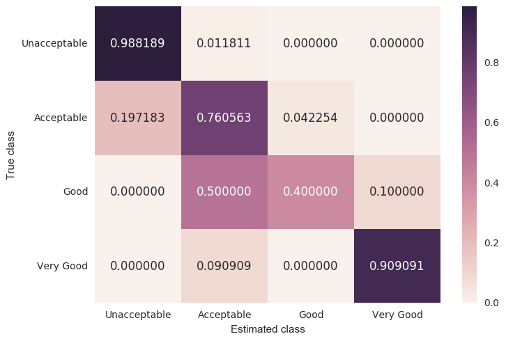

```python
labels = ['Unacceptable', 'Acceptable', 'Good', 'Very Good']
sns.heatmap(our_cf, annot=True, fmt='f',
            yticklabels=labels, xticklabels=labels)
plt.yticks(rotation=0)
plt.ylabel('True class')
plt.xlabel('Estimated class')
plt.show()
```

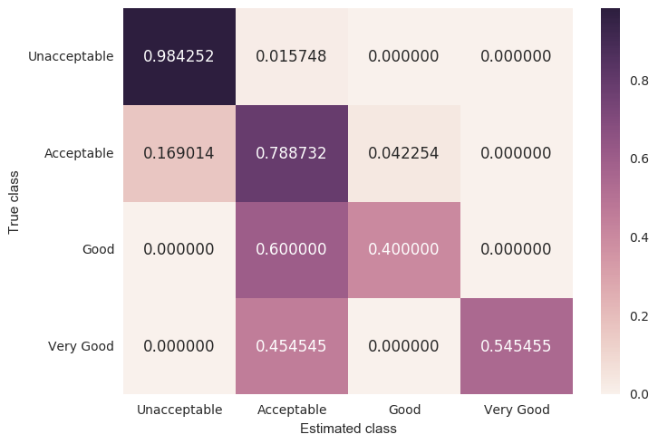

```python
sns.heatmap(sk_cf, annot=True, fmt='f',
            yticklabels=labels, xticklabels=labels)
plt.yticks(rotation=0)
plt.ylabel('True class')
plt.xlabel('Estimated class')
plt.show()
```

## Logistic Regression Class Boundaries

We wanted to get a visual of how our logistic regression divided the classes depending on features, so we plotted some class boundaries for a few sets of 2 features.

```python
# linear boundaries visualization from sklearn documentation
from matplotlib import pyplot as plt
import copy
%matplotlib inline
plt.style.use('ggplot')

def take_sample(X, y, n):
    class_amount = len(np.unique(y))
    class_indices = lambda t: [i for i,c in enumerate(y) if c == t]
    indices = np.random.choice(class_indices(1), size=n)
    y_ = [0] * n
    X_ = X[indices]

    for k in range(1,class_amount):
        indices = np.random.choice(class_indices(k), size=n)
        y_ = np.hstack(([k]*n,y_))
        X_ = np.vstack((X[indices], X_))

    return X_, y_

def plot_decision_boundaries(lr,Xin,y,title='', attr1=0,attr2=1):
    colnames=['Buying Cost','Maintanence', 'Doors', 'Persons', 'Trunk Size', 'Safety Rating', 'Class']
    Xb, y = take_sample(X, y, 60)
    #Xb = copy.deepcopy(Xin)
    lr.fit(Xb[:, :2],y) # train only on two features

    h=0.01
    # create a mesh to plot in
    x_min, x_max = Xb[:, 0].min() - 1, Xb[:, 0].max() + 1
    y_min, y_max = Xb[:, 1].min() - 1, Xb[:, 1].max() + 1
    xx, yy = np.meshgrid(np.arange(x_min, x_max, h),
                         np.arange(y_min, y_max, h))

    # get prediction values
    Z = lr.predict(np.c_[xx.ravel(), yy.ravel()])

    # Put the result into a color plot
    Z = Z.reshape(xx.shape)
    plt.contourf(xx, yy, Z, cmap=plt.cm.Paired, alpha=0.5)

    # Plot also the training points
    plt.scatter(Xb[:, attr1], Xb[:, attr2], c=y, cmap=plt.cm.Paired)
    plt.xlabel(colnames[attr1])
    plt.ylabel(colnames[attr2])
    plt.xlim(xx.min(), xx.max())
    plt.ylim(yy.min(), yy.max())
    plt.xticks(())
    plt.yticks(())
    plt.title(title)
    plt.show()

cost_vals = np.logspace(-3,-2,15)
def lr_explor(cost_idx):
    C = cost_vals[cost_idx]
    lr_clf = RegularizedLogisticRegression(eta=0.7,iterations=20, reg='L1L2',
                                   method='newton',C=0.01)

    plot_decision_boundaries(lr_clf,X,y,title="C=%.5f"%(C))

lr = LogisticRegression(0.1,1500) # this is still OUR LR implementation
```

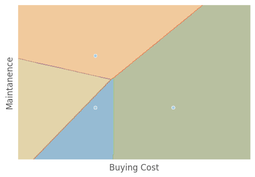

```python
plot_decision_boundaries(lr,X,y)
```

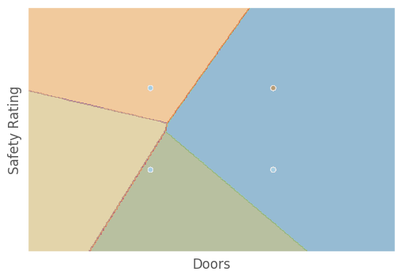

```python
plot_decision_boundaries(lr,X,y,attr1=2,attr2=5)
```

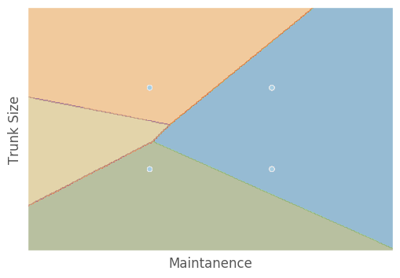

```python
plot_decision_boundaries(lr,X,y,attr1=1,attr2=4)
```

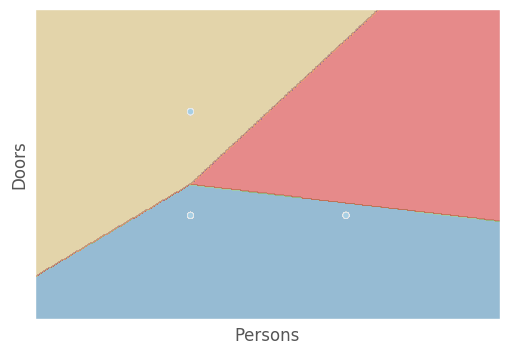

```python
plot_decision_boundaries(lr,X,y,attr1=3,attr2=2)
```

As we can see, no single combination of values is very telling as to which class the classifier will place the instance into. We thought this was really interesting as this was exactly the opposite of the case of our mushroom dataset, where any two values any combination of two values had almost 100% correlation with the final class. It's possible that we would see a much more accurate boundary when using a combination of three attributes.

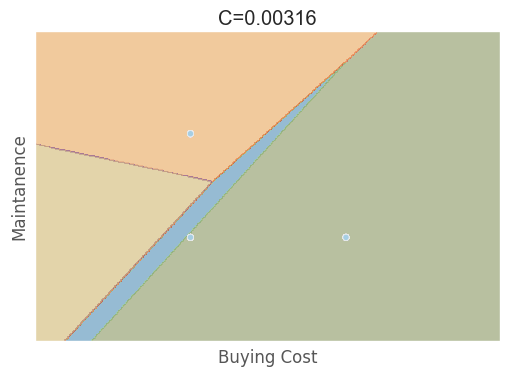

```python
from ipywidgets import widgets as wd

cost_vals = np.logspace(-3,-2,15)
def lr_explor(cost_idx):
    C = cost_vals[cost_idx]
    lr_clf = RegularizedLogisticRegression(eta=0.1,
                                           iterations=2500,
                                           C=C) # get object

    plot_decision_boundaries(lr_clf,X,y,title="C=%.5f"%(C))

wd.interact(lr_explor,cost_idx=(0,14,1),__manual=True)
```

## Deployment

Even though our implementation ended up having a higher accuracy percentage than scikit-learn, we would still recommend scikit-learn to others for two main reasons; our implementation is significantly slower and we cannot guarantee the scalability when it comes to large data sets.

The dataset we use throughout our lab is quite small compared to the many possible sets out there. We figure that scikit-learn would more than likely have better scalability purposes compared to ours considering it is widely used across the world on a huge variety of datasets and is known to work well with them.

On top of the argument relating to a bigger dataset, our solution is significantly slower than scikit-learn even though our dataset is this small. In a much larger dataset, scikit-learn is for sure going to triumph us in speed regardless if we beat them by 1%.

## GridSearchCV

For our exceptional work, we decided to make our logistic regression class compatible with scikit-learn's GridSearchCV. This was done by implementing methods that are part of the "estimator" interface, including get_params, set_params and score, as well as fit and predict which we already had implemented.

Using GridSearchCV we are able to test our class with many different combinations values for each parameter (method, C, iterations, eta). It then gives a table with each combination ranked by the accuracy score, along with other statistics like average score and time to fit. It also automatically splits the data Into test and training sets and does multiple iterations on different splits.

Since we noticed that each method runs best on different ranges of eta, C and iterations, we did 3 different runs.

```python
from sklearn.model_selection import GridSearchCV

# Steepest
parameters = {'method':('steepest',), 'C':[0.0001],
              'eta': [5,6,7,8],
              'iterations': [500]}
lr = RegularizedLogisticRegression()
clf = GridSearchCV(lr, parameters)
clf.fit(X, y)
pd.DataFrame(clf.cv_results_)
```

|  | mean_fit_time | mean_score_time | mean_test_score | mean_train_score | param_C | param_eta | param_iterations | param_method | params | rank_test_score | split0_test_score | split0_train_score | split1_test_score | split1_train_score | split2_test_score | split2_train_score | std_fit_time | std_score_time | std_test_score | std_train_score |
| --- | --- | --- | --- | --- | --- | --- | --- | --- | --- | --- | --- | --- | --- | --- | --- | --- | --- | --- | --- | --- |
| 0 | 0.003452 | 0.000397 | 0.700231 | 0.700521 | 0.0001 | 5 | 500 | steepest | {'method': 'steepest', 'iterations': 500, 'eta... | 1 | 0.862847 | 0.618924 | 0.651042 | 0.724826 | 0.586806 | 0.757812 | 0.000807 | 0.000091 | 0.117939 | 0.059249 |
| 1 | 0.002932 | 0.000335 | 0.699653 | 0.701389 | 0.0001 | 6 | 500 | steepest | {'method': 'steepest', 'iterations': 500, 'eta... | 2 | 0.857639 | 0.618924 | 0.654514 | 0.728299 | 0.586806 | 0.756944 | 0.000637 | 0.000024 | 0.115082 | 0.059473 |
| 2 | 0.002841 | 0.000331 | 0.692708 | 0.717303 | 0.0001 | 7 | 500 | steepest | {'method': 'steepest', 'iterations': 500, 'eta... | 3 | 0.814236 | 0.643229 | 0.677083 | 0.751736 | 0.586806 | 0.756944 | 0.000566 | 0.000070 | 0.093503 | 0.052421 |
| 3 | 0.003106 | 0.000335 | 0.689236 | 0.744213 | 0.0001 | 8 | 500 | steepest | {'method': 'steepest', 'iterations': 500, 'eta... | 4 | 0.789931 | 0.709201 | 0.690972 | 0.766493 | 0.586806 | 0.756944 | 0.000107 | 0.000014 | 0.082935 | 0.025062 |

```python
# Stochastic
parameters = {'method':('stochastic',), 'C':[0.0001],
              'eta': [0.1],
              'iterations': [500]}
lr = RegularizedLogisticRegression()
clf = GridSearchCV(lr, parameters)
clf.fit(X, y)
pd.DataFrame(clf.cv_results_)
```

|  | mean_fit_time | mean_score_time | mean_test_score | mean_train_score | param_C | param_eta | param_iterations | param_method | params | rank_test_score | split0_test_score | split0_train_score | split1_test_score | split1_train_score | split2_test_score | split2_train_score | std_fit_time | std_score_time | std_test_score | std_train_score |
| --- | --- | --- | --- | --- | --- | --- | --- | --- | --- | --- | --- | --- | --- | --- | --- | --- | --- | --- | --- | --- |
| 0 | 0.001032 | 0.000401 | 0.685185 | 0.694734 | 0.0001 | 0.1 | 500 | stochastic | {'method': 'stochastic', 'iterations': 500, 'e... | 1 | 0.817708 | 0.602431 | 0.651042 | 0.724826 | 0.586806 | 0.756944 | 0.000071 | 0.000108 | 0.097308 | 0.066572 |

```python
# Newton
parameters = {'method':('newton',), 'C':[0.01],
              'eta': [0.7],
              'iterations': [20]}
lr = RegularizedLogisticRegression()
clf = GridSearchCV(lr, parameters)
clf.fit(X, y)
pd.DataFrame(clf.cv_results_)
```

|  | mean_fit_time | mean_score_time | mean_test_score | mean_train_score | param_C | param_eta | param_iterations | param_method | params | rank_test_score | split0_test_score | split0_train_score | split1_test_score | split1_train_score | split2_test_score | split2_train_score | std_fit_time | std_score_time | std_test_score | std_train_score |
| --- | --- | --- | --- | --- | --- | --- | --- | --- | --- | --- | --- | --- | --- | --- | --- | --- | --- | --- | --- | --- |
| 0 | 0.10512 | 0.000376 | 0.684606 | 0.908565 | 0.01 | 0.7 | 20 | newton | {'method': 'newton', 'iterations': 20, 'eta': ... | 1 | 0.614583 | 0.877604 | 0.713542 | 0.912326 | 0.725694 | 0.935764 | 0.013627 | 0.000026 | 0.049762 | 0.023892 |

## SVMs

We also thought that it is possible that using a state vector machine could be more effective for this dataset than logistic regression. We ended up using a gamma value of .7 and testing various values of C.

```python
from sklearn import svm

max_accuracy = 0
best_C = .01
best_SVM = None

for C in np.arange(0.01,1,.01):
    rbf_svm = svm.SVC(kernel='rbf',gamma=0.7, C=C)
    rbf_svm.fit(X_train, y_train)
    y_hat = rbf_svm.predict(X_test)
    score = accuracy_score(y_test,y_hat)
    max_accuracy,best_C,best_SVM = (max_accuracy,best_C,best_SVM) if max_accuracy>score else (score,C,rbf_svm)

print("Best C value at %.2f with accuracy of %.2f" % (best_C,max_accuracy))
```

```
Best C value at 0.99 with accuracy of 0.99
```

As you can see, the SVM performed incredibly well! It seems to be a much more effective classifier on the test set than the logistical regression classifier. Our first time running this we got an accuracy of 97%, far outperforming both our logistical regression classifier and scikitlearn's logistical regression classifier. If someone was looking to deploy a classifier, we would definitely recommend the SVM over either logistical regression classifier, but if they had to use a logistical regression classifier we would still recommend scikitlearn's for the huge performance boost.

We also thought it could be interesting to try plotting the results we get from the SVM using our old "plot_decision_boundaries" function.

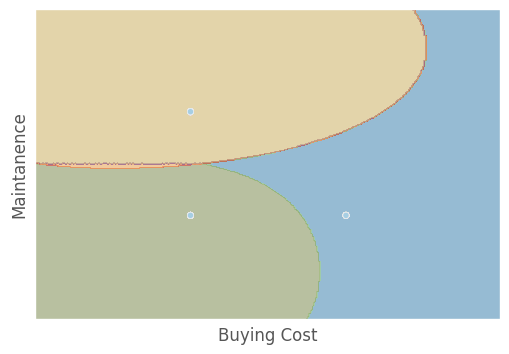

```python
plot_decision_boundaries(best_SVM,X,y)
```

#### Citations:

Professor Eric Larson, king of technology of SMU and barbarian king, lended his specatular Jupyter notebook.

SciKitLearn: http://scikit-learn.org/stable/modules/svm.html

Dataset: http://archive.ics.uci.edu/ml/datasets/Car+Evaluation